# Data Handling and Visualisation Final Report: A History of Formula 1

> The data set used for this report comes from: https://www.kaggle.com/datasets/rohanrao/formula-1-world-championship-1950-2020?select=results.csv  
> The data set contains information on the last 70 Formula 1 World Championship seasons. This report uses data from the most recent 50 years, as there was a lot of missing data from the 1952 to 1972 period.  
> The original data was stored in multiple CSV files, requiring me to create single custom dataframe using the Pandas library and the merge functionality, joining each dataframe based on the common keys found in the corresponding table.  
> Below is a table showing each attribute in the dataset, as well as a description and a data type.

| Attribute | Description | Type |
| --- | --- | --- |
| race_date | The date of the race | datetime |
| start_pos | Starting position in the race | int |
| final_pos | Finishing position in the race | int |
| final_status | The final status of the drivers race | string |
| points | Points gained from the race | float |
| laps | Total laps driven in the race | int |
| fastest_lap | The lap number of the drivers fastest lap | float |
| fastest_lap_rank | The rank of the drivers fastest lap | float |
| fastest_lap_time | The time of the drivers fastest lap | string |
| fastest_lap_speed | The fastest lap speed in km/h | float |
| race_name | The name of the race | string |
| constructor_name | The name of the constructor | string |
| constructor_nationality | The nationality of the constructor | string |
| driver_name | The name of the driver | string |
| driver_nationality | The nationality of the driver | string |
| dob | The driver's date of birth | datetime |

> The libraries used in this analysis are Pandas, for reading and storing the data, and manipulating the dataframe; Matplotlib, for creating figures and axes, and customising plot characteristics; and Seaborn, for plotting the data and creating high-level visualisations. The magic command 'matplotlib inline' is used to embed the images generated by the plot 'in' the notebook, rather than in a separate pop-up.

> When reading in the data using pandas, the 'race_date' and 'dob' columns are parsed as dates, and the 'race_date' column is then set as the index, allowing us to slice and filter the dataframe by race date, rather than arbitrary numerical indexes.

```python
# import the required libraries
import pandas as pd
import matplotlib.pyplot as plt
import seaborn as sns
%matplotlib inline

# read the data set from the csv file and store it in a Pandas dataframe, parsing the date columns and setting the index
F1 = pd.read_csv('f1_data.csv', parse_dates=['race_date', 'dob'], index_col=['race_date'])

# show the first five rows
F1.head()
```

| race_date | start_pos | final_pos | final_status | points | laps | fastest_lap | fastest_lap_rank | fastest_lap_time | fastest_lap_speed | race_name | constructor_name | constructor_nationality | dob | driver_nationality | driver_name |
| --- | --- | --- | --- | --- | --- | --- | --- | --- | --- | --- | --- | --- | --- | --- | --- |
| 1972-05-01 | 3 | 1 | Finished | 9.0 | 90 | NaN | NaN | NaN | NaN | Spanish Grand Prix | Team Lotus | British | 1946-12-12 | Brazilian | Emerson Fittipaldi |
| 1972-05-01 | 1 | 2 | Finished | 6.0 | 90 | NaN | NaN | NaN | NaN | Spanish Grand Prix | Ferrari | Italian | 1945-01-01 | Belgian | Jacky Ickx |
| 1972-05-01 | 8 | 3 | Finished | 4.0 | 89 | NaN | NaN | NaN | NaN | Spanish Grand Prix | Ferrari | Italian | 1939-05-09 | Swiss | Clay Regazzoni |
| 1972-05-01 | 13 | 4 | Finished | 3.0 | 89 | NaN | NaN | NaN | NaN | Spanish Grand Prix | Surtees | British | 1941-03-10 | Italian | Andrea de Adamich |
| 1972-05-01 | 11 | 5 | Finished | 2.0 | 89 | NaN | NaN | NaN | NaN | Spanish Grand Prix | McLaren | British | 1939-02-27 | American | Peter Revson |

## Driver Career Wins

> For the first plot, a new dataframe called 'winners' was created by using a boolean condition to filter the initial dataframe. If a row meets the condition where the 'final_pos' column equals '1', that row is then added to the new dataframe. The resulting dataframe only includes race data for winning drivers.

```python
# create new dataframe based on the boolean condition
winners = F1[(F1['final_pos'] == 1)]

# show the first five rows
winners.head()
```

| race_date | start_pos | final_pos | final_status | points | laps | fastest_lap | fastest_lap_rank | fastest_lap_time | fastest_lap_speed | race_name | constructor_name | constructor_nationality | dob | driver_nationality | driver_name |
| --- | --- | --- | --- | --- | --- | --- | --- | --- | --- | --- | --- | --- | --- | --- | --- |
| 1972-05-01 | 3 | 1 | Finished | 9.0 | 90 | NaN | NaN | NaN | NaN | Spanish Grand Prix | Team Lotus | British | 1946-12-12 | Brazilian | Emerson Fittipaldi |
| 1972-01-23 | 2 | 1 | Finished | 9.0 | 95 | NaN | NaN | NaN | NaN | Argentine Grand Prix | Tyrrell | British | 1939-11-06 | British | Jackie Stewart |
| 1972-07-02 | 3 | 1 | Finished | 9.0 | 38 | NaN | NaN | NaN | NaN | French Grand Prix | Tyrrell | British | 1939-11-06 | British | Jackie Stewart |
| 1972-03-04 | 5 | 1 | Finished | 9.0 | 79 | NaN | NaN | NaN | NaN | South African Grand Prix | McLaren | British | 1936-06-18 | New Zealander | Denny Hulme |
| 1972-06-04 | 1 | 1 | Finished | 9.0 | 85 | NaN | NaN | NaN | NaN | Belgian Grand Prix | Team Lotus | British | 1946-12-12 | Brazilian | Emerson Fittipaldi |

> The following count plot was created using Seaborn. It uses the winners dataframe and it counts the occurence of a drivers name, giving us the total wins they've achieved over their career. Two drivers stand out amongst the group, and unsurprisingly these two drivers are widely considered the two greatest drivers of all time, Lewis Hamilton and Michael Schumacher. An honorable mention goes to Sebastian Vettel and Alan Prost, who between them have a combined 7 World Driver Championships.

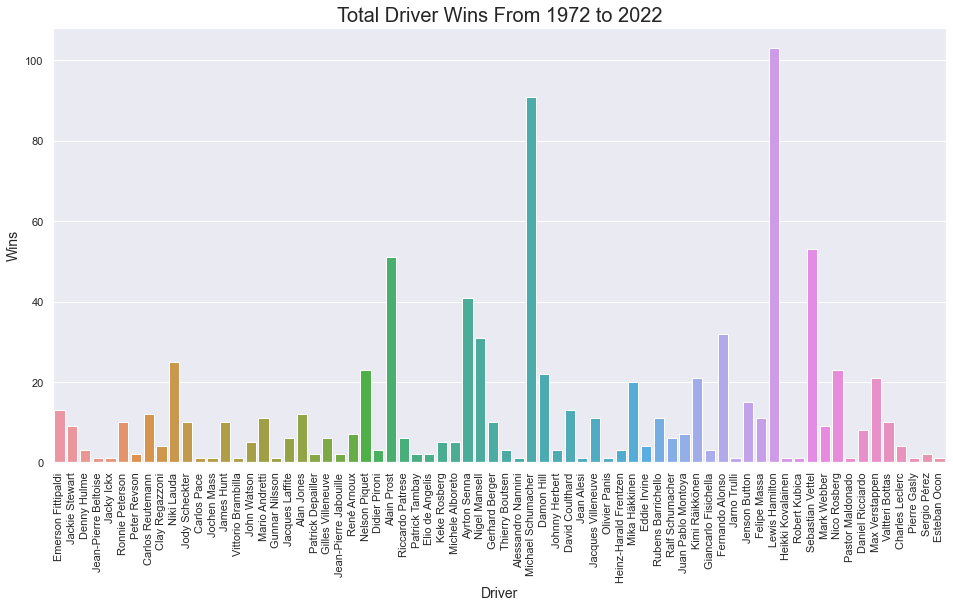

```python
# set the seaborn colour theme for the notebook
sns.set_theme()

# create the figure and the axes, and plot the data using a Seaborn count plot
fig, ax = plt.subplots(figsize=(16,8))
ax = sns.countplot(x='driver_name', data=winners)

# customise plot
ax.set_title('Total Driver Wins From 1972 to 2022', fontsize=20)
ax.set_xlabel('Driver', fontsize=14)
ax.set_ylabel('Wins', fontsize=14)
plt.xticks(rotation=90)
plt.show()
```

## The Age of Winning Drivers

> To calculate the age of each winning driver, I've created a new column called 'winner_age', by subtracting the year the driver was born from the year the race took place. I sliced each column using the loc function which takes an index label (the column name) as the parameter. Then, as the datatype of each Series was a datetime object, I was able to directly access the year attribute using the 'dt' method. I also calculated the mean of the winning age distribution using the mean() function, to use for further analysis in addition to the histogram.

```python
# reset the index to make location based slicing easier
winners = winners.reset_index()

# create a new column using the year attributes from the datetime objects
winners.loc[:,'winner_age'] = winners.loc[:,'race_date'].dt.year - winners.loc[:,'dob'].dt.year
```

```python
# calculate the mean winner's age
print('The mean winning age is:', round(winners['winner_age'].mean(),2))
```

```
The mean winning age is: 30.42
```

> A Seaborn histogram is used to plot the age distribution, with the age on the x-axis, and the count on the y-axis. The data is approximately normally distributed around the age of 30, which is inline with our mean calculation (30.42) from the previous cell, and most of the wins occur between the age of 25 and 35.  
> Many drivers begin their career in their late teens, or early twenties, so we can conclude from this data that it takes a long time, on average, for a driver to start winning races. Aside from driver experience, this is likely due to the fact that most drivers start at a lower tier team, before working their way up the ladder, as only a handful of teams are able to compete for wins given the wide disparity in team finances.

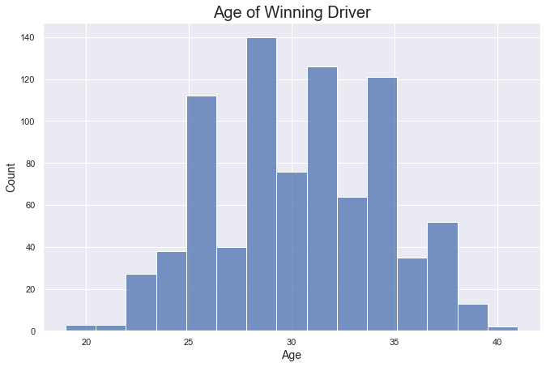

```python
# create the figure and axes
f, ax = plt.subplots(figsize=(11, 7))
ax = sns.histplot(x='winner_age', data=winners)

# customise the plot
ax.set_title('Age of Winning Driver', fontsize=20)
ax.set_xlabel('Age', fontsize=14)
ax.set_ylabel('Count', fontsize=14)
```

## Total Constructor Wins

> A horizontal count plot is used to show the total wins by constructor over the previous 50 years of Formula 1. The constructors with the most wins are Ferrari and Mclaren, with Williams and Mercedes equal third. This is an impressive feat for Mercedes given they only returned to the sport in 2010 after a multi-decade hiatus.

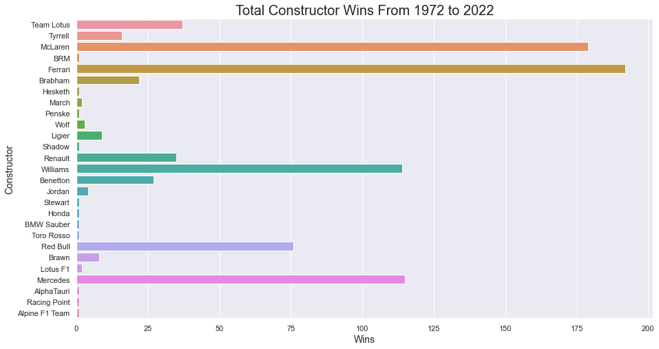

```python
# create the figure and axes
f, ax = plt.subplots(figsize=(15, 8))
ax = sns.countplot(y='constructor_name', data=winners)

# customise plot
ax.set_title('Total Constructor Wins From 1972 to 2022', fontsize=20)
ax.set_xlabel('Wins', fontsize=14)
ax.set_ylabel('Constructor', fontsize=14)
```

## Comparing Final Race Status Over Two 25 Year Periods

> For the next plot, I created two new dataframes representing the first 25 years, and second 25 years of data. By resetting the index, replacing the date with a standard numerical index, I was able to split the original dataframe in half with some simple arithmetic. This was done by calculating the amount of rows using the length function, then dividing it by two to find the mid point. These parameters were passed to the iloc function, which selects the row/column slice by index numbers.

```python
# reset the index and temporarily store the data in a new df
temp_f1 = F1.reset_index()

# create two new data frames splitting the data in half
first_25 = temp_f1.iloc[0:round(len(temp_f1)/2),:]
last_25 = temp_f1.iloc[round(len(temp_f1)/2):(len(temp_f1)+1),:]
```

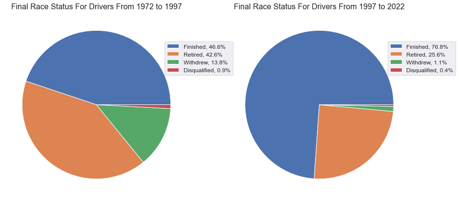

```python
# create the legend labels for each pie plot
status = F1['final_status'].unique().tolist()
labels1 = [f'{l}, {s/100:0.1f}%' for l, s in zip(status, first_25.final_status.value_counts())]
labels2 = [f'{l}, {s/100:0.1f}%' for l, s in zip(status, last_25.final_status.value_counts())]

# create the figure and subplots
fig, ax = plt.subplots(nrows=1, ncols=2, figsize=(15,8))

# plot and customise chart 1
first_25.final_status.value_counts().plot(kind='pie', ax=ax[0], labels=None)
ax[0].legend(labels = labels1, loc='right', bbox_to_anchor=(1.25,0.75), fontsize=12)
ax[0].set_ylabel('')
ax[0].set_title('Final Race Status For Drivers From 1972 to 1997', fontsize=16)

# plot and customise chart 2
last_25.final_status.value_counts().plot(kind='pie', ax=ax[1], labels=None)
ax[1].legend(labels = labels2, loc='right', bbox_to_anchor=(1.25,0.75), fontsize=12)
ax[1].set_ylabel('')
ax[1].set_title('Final Race Status For Drivers From 1997 to 2022', fontsize=16)
```

## Season 2021 Analysis

> The following four plots will take a deeper look into the most recent 2021 calendar year. For this analysis, I've created a new dataframe, sliced using the loc fuction, with the start and end dates used as the parameters. A preview of the dataframe is then shown using the head() function.

```python
# slice the data based on index loc, generating a df for season 2021
season_21 = F1.loc['2021-01-01':'2021-12-31',:]

# show a preview of the first 5 rows
season_21.head()
```

| race_date | start_pos | final_pos | final_status | points | laps | fastest_lap | fastest_lap_rank | fastest_lap_time | fastest_lap_speed | race_name | constructor_name | constructor_nationality | dob | driver_nationality | driver_name |
| --- | --- | --- | --- | --- | --- | --- | --- | --- | --- | --- | --- | --- | --- | --- | --- |
| 2021-03-28 | 2 | 1 | Finished | 25.0 | 56 | 44.0 | 4.0 | 94.0 | 207.235 | Bahrain Grand Prix | Mercedes | German | 1985-07-01 | British | Lewis Hamilton |
| 2021-03-28 | 1 | 2 | Finished | 18.0 | 56 | 41.0 | 2.0 | 93.2 | 208.984 | Bahrain Grand Prix | Red Bull | Austrian | 1997-09-30 | Dutch | Max Verstappen |
| 2021-03-28 | 3 | 3 | Finished | 16.0 | 56 | 56.0 | 1.0 | 92.1 | 211.566 | Bahrain Grand Prix | Mercedes | German | 1989-08-28 | Finnish | Valtteri Bottas |
| 2021-03-28 | 7 | 4 | Finished | 12.0 | 56 | 38.0 | 6.0 | 94.4 | 206.398 | Bahrain Grand Prix | McLaren | British | 1999-11-13 | British | Lando Norris |
| 2021-03-28 | 0 | 5 | Finished | 10.0 | 56 | 44.0 | 3.0 | 94.0 | 207.334 | Bahrain Grand Prix | Red Bull | Austrian | 1990-01-26 | Mexican | Sergio Pérez |

> The pivot function allowed me to reshape the data to the required format for the heatmap visualisation. It takes 3 columns as parameters, and returns a new dataframe using the first input as the index, the second input as the column headings, and the third input as the corresponding values. The columns were then reordered such that the races were in chronological order.

```python
# create new df and pivot the data for a heatmap
s21_heatmap = season_21.pivot('driver_name', 'race_name', 'final_pos')

# change the order of the columns so the races are in chronological order
s21_heatmap = s21_heatmap[['Bahrain Grand Prix', 'Emilia Romagna Grand Prix', 'Portuguese Grand Prix', 'Spanish Grand Prix',
                             'Monaco Grand Prix', 'Azerbaijan Grand Prix', 'French Grand Prix', 'Styrian Grand Prix',
                             'Austrian Grand Prix', 'British Grand Prix', 'Hungarian Grand Prix', 'Belgian Grand Prix',
                             'Dutch Grand Prix', 'Italian Grand Prix', 'Russian Grand Prix', 'Turkish Grand Prix',
                             'United States Grand Prix', 'Mexico City Grand Prix', 'São Paulo Grand Prix', 'Qatar Grand Prix',
                             'Saudi Arabian Grand Prix', 'Abu Dhabi Grand Prix']]

# show a preview of the first 5 rows
s21_heatmap.head()
```

| race_name driver_name | Bahrain Grand Prix | Emilia Romagna Grand Prix | Portuguese Grand Prix | Spanish Grand Prix | Monaco Grand Prix | Azerbaijan Grand Prix | French Grand Prix | Styrian Grand Prix | Austrian Grand Prix | British Grand Prix | ... | Dutch Grand Prix | Italian Grand Prix | Russian Grand Prix | Turkish Grand Prix | United States Grand Prix | Mexico City Grand Prix | São Paulo Grand Prix | Qatar Grand Prix | Saudi Arabian Grand Prix | Abu Dhabi Grand Prix |
| --- | --- | --- | --- | --- | --- | --- | --- | --- | --- | --- | --- | --- | --- | --- | --- | --- | --- | --- | --- | --- | --- |
| Antonio Giovinazzi | 12.0 | 14.0 | 12.0 | 15.0 | 10.0 | 11.0 | 15.0 | 15.0 | 14.0 | 13.0 | ... | 14.0 | 13.0 | 16.0 | 11.0 | 11.0 | 11.0 | 14.0 | 15.0 | 9.0 | 17.0 |
| Carlos Sainz | 8.0 | 5.0 | 11.0 | 7.0 | 2.0 | 8.0 | 11.0 | 6.0 | 5.0 | 6.0 | ... | 7.0 | 6.0 | 3.0 | 8.0 | 7.0 | 6.0 | 6.0 | 7.0 | 8.0 | 3.0 |
| Charles Leclerc | 6.0 | 4.0 | 6.0 | 4.0 | 20.0 | 4.0 | 16.0 | 7.0 | 8.0 | 2.0 | ... | 5.0 | 4.0 | 15.0 | 4.0 | 4.0 | 5.0 | 5.0 | 8.0 | 7.0 | 10.0 |
| Daniel Ricciardo | 7.0 | 6.0 | 9.0 | 6.0 | 12.0 | 9.0 | 6.0 | 13.0 | 7.0 | 5.0 | ... | 11.0 | 1.0 | 4.0 | 13.0 | 5.0 | 12.0 | 19.0 | 12.0 | 5.0 | 12.0 |
| Esteban Ocon | 13.0 | 9.0 | 7.0 | 9.0 | 9.0 | 20.0 | 14.0 | 14.0 | 20.0 | 9.0 | ... | 9.0 | 10.0 | 14.0 | 10.0 | 19.0 | 13.0 | 8.0 | 5.0 | 4.0 | 9.0 |

5 rows × 22 columns

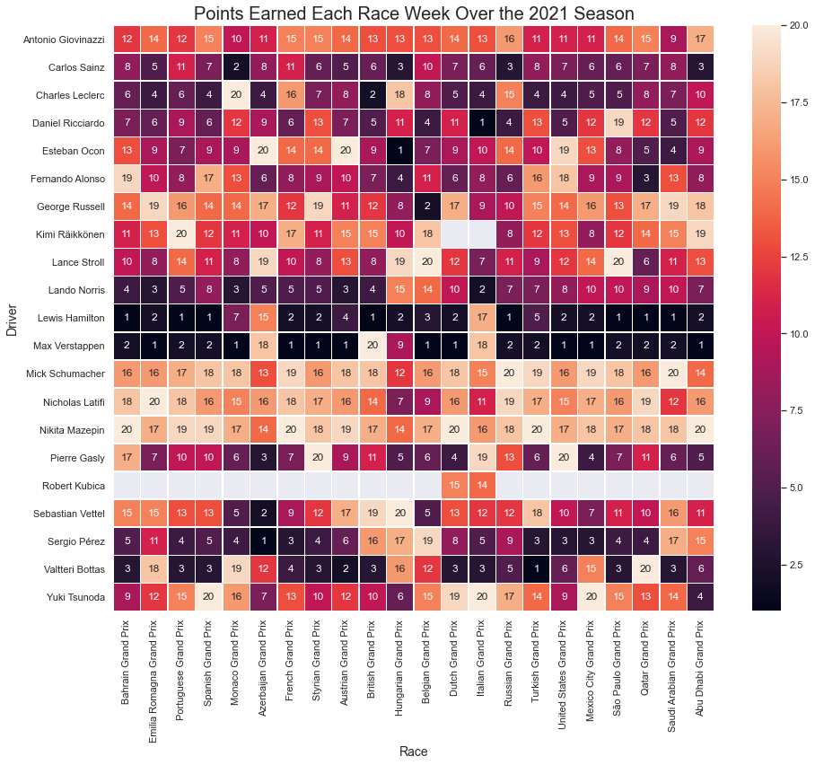

```python
# Draw a heatmap
f, ax = plt.subplots(figsize=(15, 12))
ax = sns.heatmap(s21_heatmap, annot=True, linewidths=.5)

# customise plot
ax.set_title('Points Earned Each Race Week Over the 2021 Season', fontsize=20)
ax.set_xlabel('Race', fontsize=14)
ax.set_ylabel('Driver', fontsize=14)
```

> Another way to visualise points earned throughout the season, and the dominance of the two best drivers, is by plotting the cumulative points earned by each driver as the season progressed. Using a similar pivot approach, I was able to sum the points earned by each driver using the cumsum() function. The resulting dataframe was then used to create a Seaborn line plot. The dominance of the two drivers is clear to see, and gap between them and the rest of the field only widened as the season progressed.

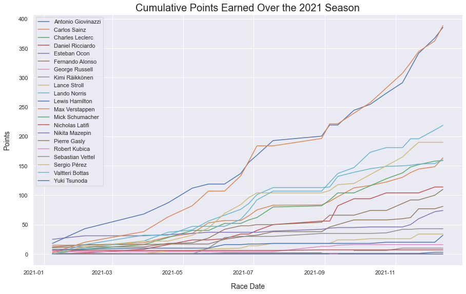

```python
# reset the index and create a new pivot table from the dataframe
s21_points = season_21.reset_index()
s21_points = s21_points.pivot('race_date', 'driver_name', 'points')
s21_points = s21_points.cumsum()

# create the figure and axes
fig, ax = plt.subplots(figsize=(15,10))

# plot the data frame on the axes
s21_points.plot(ax=ax)

# customise plot
ax.legend(title=None)
ax.set_title('Cumulative Points Earned Over the 2021 Season', fontsize=20)
ax.set_xlabel('Race Date', fontsize=14, labelpad=15)
plt.xticks(rotation=0)
ax.set_ylabel('Points', fontsize=14, labelpad=15)
```

## Visualising the Position Differential of Each Driver

> For the next plot, a new column called 'position_diff' was created by subtracting the finish position from the start position for each driver, for each race over the season. This provides us with look at how well drivers were able to make up ground throughout the race, or if they generally lost positions after qualifying.

```python
# create a new column called position difference: start position - finish position
season_21['position_diff'] = season_21['start_pos'] - season_21['final_pos']

# show the first 5 rows
season_21.head()
```

| race_date | start_pos | final_pos | final_status | points | laps | fastest_lap | fastest_lap_rank | fastest_lap_time | fastest_lap_speed | race_name | constructor_name | constructor_nationality | dob | driver_nationality | driver_name | position_diff |
| --- | --- | --- | --- | --- | --- | --- | --- | --- | --- | --- | --- | --- | --- | --- | --- | --- |
| 2021-03-28 | 2 | 1 | Finished | 25.0 | 56 | 44.0 | 4.0 | 94.0 | 207.235 | Bahrain Grand Prix | Mercedes | German | 1985-07-01 | British | Lewis Hamilton | 1 |
| 2021-03-28 | 1 | 2 | Finished | 18.0 | 56 | 41.0 | 2.0 | 93.2 | 208.984 | Bahrain Grand Prix | Red Bull | Austrian | 1997-09-30 | Dutch | Max Verstappen | -1 |
| 2021-03-28 | 3 | 3 | Finished | 16.0 | 56 | 56.0 | 1.0 | 92.1 | 211.566 | Bahrain Grand Prix | Mercedes | German | 1989-08-28 | Finnish | Valtteri Bottas | 0 |
| 2021-03-28 | 7 | 4 | Finished | 12.0 | 56 | 38.0 | 6.0 | 94.4 | 206.398 | Bahrain Grand Prix | McLaren | British | 1999-11-13 | British | Lando Norris | 3 |
| 2021-03-28 | 0 | 5 | Finished | 10.0 | 56 | 44.0 | 3.0 | 94.0 | 207.334 | Bahrain Grand Prix | Red Bull | Austrian | 1990-01-26 | Mexican | Sergio Pérez | -5 |

> Lewis Hamilton, Lando Norris, and Estaban Ocon showed an impressive level of consistancy with minimal variance. While Sergio Perez and Pierre Gasly, who are both considered to be some of the most talented drivers on the grid, had statistically poor seasons, with a negative differential and a large variance in their performances.

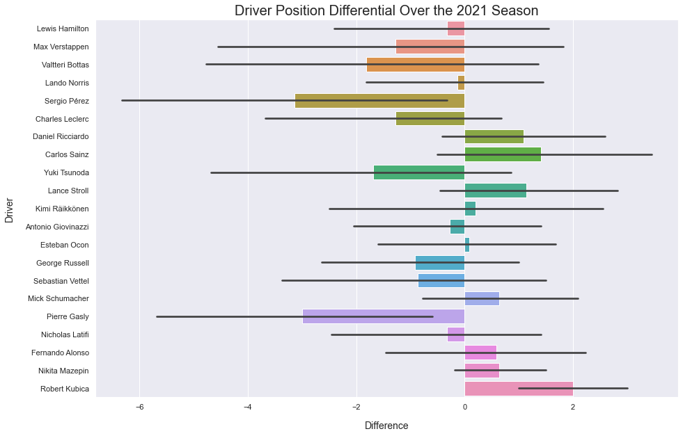

```python
# draw a bar plot using seaborn
# create the figure and axes
fig, ax = plt.subplots(figsize=(15,10))
ax = sns.barplot(x="position_diff", y="driver_name", data=season_21)

# customise the plot
ax.set_title('Driver Position Differential Over the 2021 Season', fontsize=20)
ax.set_xlabel('Difference', fontsize=14, labelpad=15)
ax.set_ylabel('Driver', fontsize=14, labelpad=15)
```

## Lap Times Over the 2021 Season

> The final plot uses the subplot functionality of Matplotlib, which allows us to plot multiple box plots on an underlying grid. To prepare the data for this plot, I created a list containing the names of each race, using the unique() function to remove duplicates. The Belgian Grand Prix was removed from the list as lap time data was missing for this race.

> To cleanly plot the data, I used a loop and the zip function, which creates a tuple of the two objects passed as parameters, allowing us to iterate over them; and the ravel() function, which converts the axs from a two-dimensional array to a one-dimensional array, allowing us to iterate over it sequentially. I then plotted the unique race name's on the y-axis, using the boolean conditional filter, and the lap times of each driver on the x-axis.

> We can see a mostly tight spread in the data for each race, evidenced by the relatively small range in x-tick values. There will always be outliers, as some cars suffer mechanical or performance issues, but for the most part, there isn't a lot to split the cars on a lap-by-lap basis.

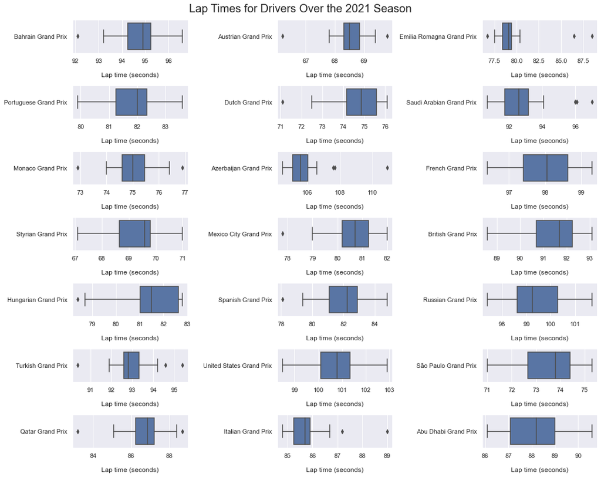

```python
# create a list of races by using the unique function on the race_name Series, and then convert it to a list
races = season_21['race_name'].unique().tolist()
races.remove('Belgian Grand Prix')

# create the subplot and axes, and set the figure title
fig, axs = plt.subplots(nrows=7, ncols=3, figsize=(15, 12))
fig.suptitle("Lap Times for Drivers Over the 2021 Season", fontsize=20)

# loop through the race list and axs, using the ravel function, which converts it from a 2d to 1d array
for race, ax in zip(races, axs.ravel()):
    # filter df for ticker and plot on specified axes
    sns.boxplot(y=season_21[(season_21['race_name'] == race)]['race_name'], x='fastest_lap_time', data=season_21, ax=ax)
    ax.set_xlabel('Lap time (seconds)', labelpad=15)
    ax.set_ylabel('')

# remove unnecessary space
fig.tight_layout()
```